[figure not shown]

[figure not shown]

# Model fit

### Assumption checks

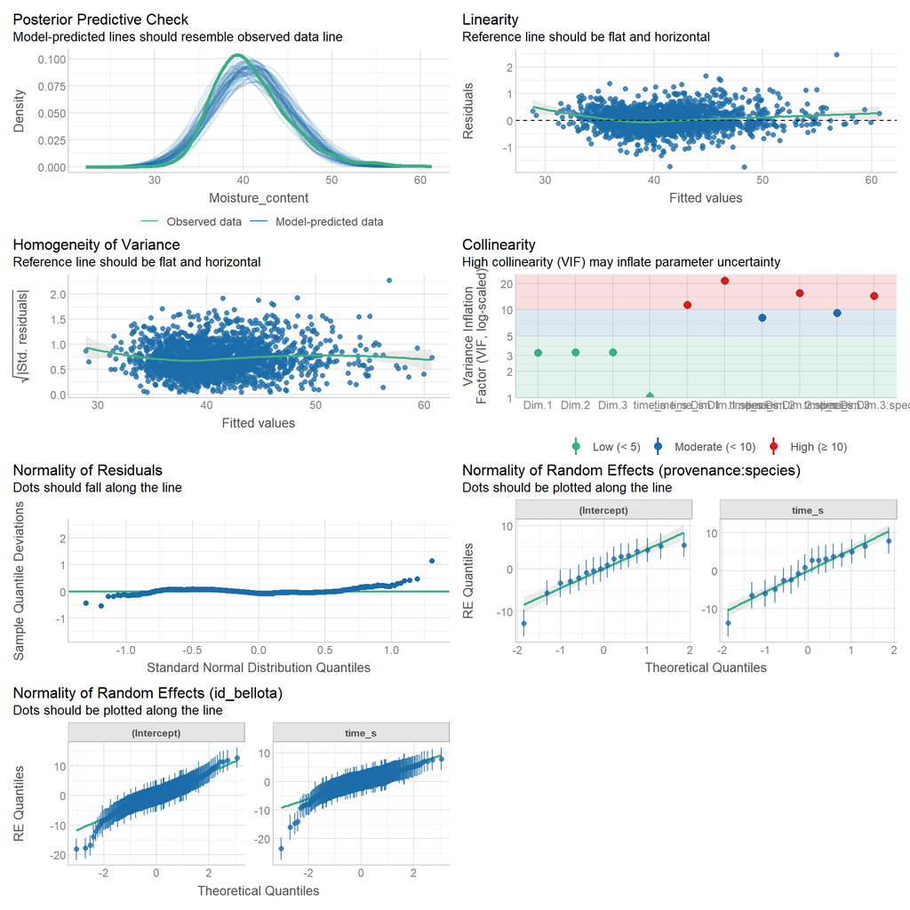

### Indices of model fit

| Metric | Value |
| --- | --- |
| AIC | 5739.8 |
| AICc | 5741.1 |
| BIC | 5942.6 |
| R2 (cond.) | 0.99 |
| R2 (marg.) | 0.33 |
| ICC | 0.98 |
| RMSE | 0.37 |
| Sigma | 0.47 |

For interpretation of performance metrics, please refer to [this documentation](https://easystats.github.io/performance/reference/model_performance.html).

# Parameter estimates

### Plot

[figure not shown]

### Tabular summary

Fixed Effects

| Parameter | Coefficient | SE | 95% CI | z | p |
| --- | --- | --- | --- | --- | --- |
| (Intercept) | 23.87 | 1.19 | (21.54, 26.20) | 20.12 | < .001 |
| time s | -18.35 | 1.43 | (-21.15, -15.55) | -12.86 | < .001 |
| Dim 1 | 1.13 | 0.20 | (0.74, 1.52) | 5.64 | < .001 |
| Dim 2 | -1.01 | 0.27 | (-1.54, -0.47) | -3.68 | < .001 |
| Dim 3 | -0.69 | 0.27 | (-1.22, -0.15) | -2.52 | 0.012 |
| time s × Dim 1 | 1.52 | 0.34 | (0.85, 2.18) | 4.50 | < .001 |
| time s × Dim 2 | -0.75 | 0.39 | (-1.51, 0.02) | -1.91 | 0.056 |
| time s × Dim 3 | -1.10 | 0.41 | (-1.90, -0.30) | -2.69 | 0.007 |
| time s × Dim 1 × speciesQuercus faginea | 0.27 | 0.56 | (-0.83, 1.37) | 0.48 | 0.634 |
| time s × Dim 1 × speciesQuercus ilex | 0.09 | 0.38 | (-0.65, 0.83) | 0.23 | 0.815 |
| time s × Dim 1 × speciesQuercus petraea | 1.54 | 0.41 | (0.74, 2.34) | 3.77 | < .001 |
| time s × Dim 1 × speciesQuercus pubescens | 0.93 | 0.56 | (-0.18, 2.04) | 1.65 | 0.099 |
| time s × Dim 1 × speciesQuercus pyrenaica | 0.27 | 0.40 | (-0.52, 1.05) | 0.66 | 0.509 |
| time s × Dim 1 × speciesQuercus robur | -0.61 | 0.47 | (-1.53, 0.31) | -1.30 | 0.195 |
| time s × Dim 1 × speciesQuercus suber | -0.04 | 0.44 | (-0.90, 0.83) | -0.08 | 0.935 |
| time s × Dim 2 × speciesQuercus faginea | 1.07 | 0.56 | (-0.03, 2.16) | 1.91 | 0.057 |
| time s × Dim 2 × speciesQuercus ilex | -0.49 | 0.47 | (-1.41, 0.42) | -1.06 | 0.289 |
| time s × Dim 2 × speciesQuercus petraea | -0.94 | 0.48 | (-1.88, -3.57e-03) | -1.97 | 0.049 |
| time s × Dim 2 × speciesQuercus pubescens | -0.68 | 0.71 | (-2.07, 0.72) | -0.95 | 0.341 |
| time s × Dim 2 × speciesQuercus pyrenaica | -0.24 | 0.63 | (-1.47, 1.00) | -0.37 | 0.708 |
| time s × Dim 2 × speciesQuercus robur | -0.37 | 0.62 | (-1.58, 0.84) | -0.59 | 0.553 |
| time s × Dim 2 × speciesQuercus suber | 0.64 | 0.56 | (-0.46, 1.73) | 1.14 | 0.253 |
| time s × Dim 3 × speciesQuercus faginea | 0.56 | 0.62 | (-0.66, 1.78) | 0.89 | 0.371 |
| time s × Dim 3 × speciesQuercus ilex | 0.70 | 0.54 | (-0.36, 1.75) | 1.30 | 0.195 |
| time s × Dim 3 × speciesQuercus petraea | -0.08 | 0.50 | (-1.06, 0.89) | -0.16 | 0.870 |
| time s × Dim 3 × speciesQuercus pubescens | 0.79 | 0.60 | (-0.39, 1.97) | 1.31 | 0.191 |
| time s × Dim 3 × speciesQuercus pyrenaica | 1.18 | 0.51 | (0.17, 2.19) | 2.29 | 0.022 |
| time s × Dim 3 × speciesQuercus robur | -0.21 | 0.56 | (-1.30, 0.88) | -0.38 | 0.701 |
| time s × Dim 3 × speciesQuercus suber | 0.92 | 0.55 | (-0.16, 1.99) | 1.67 | 0.095 |

Random Effects

| Parameter | Coefficient |
| --- | --- |
| SD (Intercept: provenance:species) | 4.66 |
| SD (Intercept: id_bellota) | 4.32 |
| SD (time_s: provenance:species) | 5.59 |
| SD (time_s: id_bellota) | 3.70 |
| Cor (Intercept~time_s: provenance:species) | 0.90 |
| Cor (Intercept~time_s: id_bellota) | 0.80 |
| SD (Residual) | 0.47 |

To find out more about table summary options, please refer to [this documentation](https://easystats.github.io/parameters/reference/model_parameters.html).

# Predicted Values

### Plot

[output not shown]

# Text reports

### Textual summary

We fitted a linear mixed model (estimated using ML and nlminb optimizer) to predict Moisture_content with time_s, Dim.1, Dim.2, Dim.3 and species (formula: Moisture_content ~ time_s * (Dim.1 + Dim.2 + Dim.3) + time_s:Dim.1:species + time_s:Dim.2:species + time_s:Dim.3:species). The model included time_s as random effects (formula: list(~time_s | provenance:species, ~time_s | id_bellota)). The model’s total explanatory power is substantial (conditional R2 = 0.99) and the part related to the fixed effects alone (marginal R2) is of 0.33. The model’s intercept, corresponding to time_s = 0, Dim.1 = 0, Dim.2 = 0, Dim.3 = 0 and species = Quercus coccifera, is at 23.87 (95% CI (21.54, 26.20), p < .001). Within this model:

- The effect of time s is statistically significant and negative (beta = -18.35, 95% CI (-21.15, -15.55), p < .001)
- The effect of Dim 1 is statistically significant and positive (beta = 1.13, 95% CI (0.74, 1.52), p < .001)
- The effect of Dim 2 is statistically significant and negative (beta = -1.01, 95% CI (-1.54, -0.47), p < .001)
- The effect of Dim 3 is statistically significant and negative (beta = -0.69, 95% CI (-1.22, -0.15), p = 0.012)
- The effect of time s × Dim 1 is statistically significant and positive (beta = 1.52, 95% CI (0.85, 2.18), p < .001)
- The effect of time s × Dim 2 is statistically non-significant and negative (beta = -0.75, 95% CI (-1.51, 0.02), p = 0.056)
- The effect of time s × Dim 3 is statistically significant and negative (beta = -1.10, 95% CI (-1.90, -0.30), p = 0.007)
- The effect of time s × Dim 1 × speciesQuercus faginea is statistically non-significant and positive (beta = 0.27, 95% CI (-0.83, 1.37), p = 0.634)
- The effect of time s × Dim 1 × speciesQuercus ilex is statistically non-significant and positive (beta = 0.09, 95% CI (-0.65, 0.83), p = 0.815)
- The effect of time s × Dim 1 × speciesQuercus petraea is statistically significant and positive (beta = 1.54, 95% CI (0.74, 2.34), p < .001)
- The effect of time s × Dim 1 × speciesQuercus pubescens is statistically non-significant and positive (beta = 0.93, 95% CI (-0.18, 2.04), p = 0.099)
- The effect of time s × Dim 1 × speciesQuercus pyrenaica is statistically non-significant and positive (beta = 0.27, 95% CI (-0.52, 1.05), p = 0.509)
- The effect of time s × Dim 1 × speciesQuercus robur is statistically non-significant and negative (beta = -0.61, 95% CI (-1.53, 0.31), p = 0.195)
- The effect of time s × Dim 1 × speciesQuercus suber is statistically non-significant and negative (beta = -0.04, 95% CI (-0.90, 0.83), p = 0.935)
- The effect of time s × Dim 2 × speciesQuercus faginea is statistically non-significant and positive (beta = 1.07, 95% CI (-0.03, 2.16), p = 0.057)
- The effect of time s × Dim 2 × speciesQuercus ilex is statistically non-significant and negative (beta = -0.49, 95% CI (-1.41, 0.42), p = 0.289)
- The effect of time s × Dim 2 × speciesQuercus petraea is statistically significant and negative (beta = -0.94, 95% CI (-1.88, -3.57e-03), p = 0.049)
- The effect of time s × Dim 2 × speciesQuercus pubescens is statistically non-significant and negative (beta = -0.68, 95% CI (-2.07, 0.72), p = 0.341)
- The effect of time s × Dim 2 × speciesQuercus pyrenaica is statistically non-significant and negative (beta = -0.24, 95% CI (-1.47, 1.00), p = 0.708)
- The effect of time s × Dim 2 × speciesQuercus robur is statistically non-significant and negative (beta = -0.37, 95% CI (-1.58, 0.84), p = 0.553)
- The effect of time s × Dim 2 × speciesQuercus suber is statistically non-significant and positive (beta = 0.64, 95% CI (-0.46, 1.73), p = 0.253)
- The effect of time s × Dim 3 × speciesQuercus faginea is statistically non-significant and positive (beta = 0.56, 95% CI (-0.66, 1.78), p = 0.371)
- The effect of time s × Dim 3 × speciesQuercus ilex is statistically non-significant and positive (beta = 0.70, 95% CI (-0.36, 1.75), p = 0.195)
- The effect of time s × Dim 3 × speciesQuercus petraea is statistically non-significant and negative (beta = -0.08, 95% CI (-1.06, 0.89), p = 0.870)
- The effect of time s × Dim 3 × speciesQuercus pubescens is statistically non-significant and positive (beta = 0.79, 95% CI (-0.39, 1.97), p = 0.191)
- The effect of time s × Dim 3 × speciesQuercus pyrenaica is statistically significant and positive (beta = 1.18, 95% CI (0.17, 2.19), p = 0.022)
- The effect of time s × Dim 3 × speciesQuercus robur is statistically non-significant and negative (beta = -0.21, 95% CI (-1.30, 0.88), p = 0.701)
- The effect of time s × Dim 3 × speciesQuercus suber is statistically non-significant and positive (beta = 0.92, 95% CI (-0.16, 1.99), p = 0.095)

Standardized parameters were obtained by fitting the model on a standardized version of the dataset. 95% Confidence Intervals (CIs) and p-values were computed using a Wald z-distribution approximation. The model’s total explanatory power is substantial (conditional R2 = 0.99) and the part related to the fixed effects alone (marginal R2) is of 0.33

### Model information

|  | name | value |
| --- | --- | --- |
| 1 | is_binomial | FALSE |
| 2 | is_bernoulli | FALSE |
| 3 | is_count | FALSE |
| 4 | is_poisson | FALSE |
| 5 | is_negbin | FALSE |
| 6 | is_beta | FALSE |
| 7 | is_betabinomial | FALSE |
| 8 | is_orderedbeta | FALSE |
| 9 | is_dirichlet | FALSE |
| 10 | is_exponential | FALSE |

[output cut: 198 more lines]

````r
---
title: "Regression model summary from `{easystats}`"
output:
  flexdashboard::flex_dashboard:
    theme:
      version: 4
      # bg: "#101010"
      # fg: "#FDF7F7"
      primary: "#0054AD"
      base_font:
        google: Prompt
      code_font:
        google: JetBrains Mono
params:
  model: model
  check_model_args: check_model_args
  parameters_args: parameters_args
  performance_args: performance_args
---

```{r setup, include=FALSE}
library(flexdashboard)
library(easystats)

# Since not all regression model are supported across all packages, make the
# dashboard chunks more fault-tolerant. E.g. a model might be supported in
# `{parameters}`, but not in `{report}`.
#
# For this reason, `error = TRUE`
knitr::opts_chunk$set(
  error = TRUE,
  out.width = "100%"
)

# helper function for printing `{report}` outputs
bracket_to_parantheses <- function(text) {
  gsub("]", ")", gsub("[", "(", text, fixed = TRUE), fixed = TRUE)
}
```

```{r easydashboard-1}
# Get user-specified model data
model <- params$model

# Is it supported by `{easystats}`? Skip evaluation of the following chunks if not.
is_supported <- insight::is_model_supported(model)

if (!is_supported) {
  unsupported_message <- sprintf(
    "Unfortunately, objects of class `%s` are not yet supported in {easystats}.\n
    For a list of supported models, see `insight::supported_models()`.",
    class(model)[1]
  )
}
```


Model fit
=====================================

Column {data-width=700}
-----------------------------------------------------------------------

### Assumption checks

```{r check-model, eval=is_supported, fig.height=10, fig.width=10}
check_model_args <- c(list(model), params$check_model_args)
# add verbose, if not done yet
if (is.null(check_model_args$verbose)) check_model_args$verbose <- FALSE
tryCatch(
  {
    do.call(performance::check_model, check_model_args)
  },
  error = function(e) {
    cat(insight::format_message(
      "\nSomething did not work as expected. Please file an issue at {.url https://github.com/easystats/easystats/issues/} and post the following output:",
      paste0("\n`", e$message, "`")
    ))
  }
)
```

```{r easydashboard-2, eval=!is_supported}
cat(unsupported_message)
```

Column {data-width=300}
-----------------------------------------------------------------------

### Indices of model fit

```{r easydashboard-3, eval=is_supported}
# {performance}
performance_args <- c(list(model), params$performance_args)
# add verbose, if not done yet
if (is.null(performance_args$verbose)) performance_args$verbose <- FALSE
table_performance <- do.call(performance::performance, performance_args)
print_md(table_performance, layout = "vertical", caption = NULL)
```


```{r easydashboard-4, eval=!is_supported}
cat(unsupported_message)
```

For interpretation of performance metrics, please refer to <a href="https://easystats.github.io/performance/reference/model_performance.html" target="_blank">this documentation</a>.

Parameter estimates
=====================================

Column {data-width=550}
-----------------------------------------------------------------------

### Plot

```{r dot-whisker, eval=is_supported}
# `{parameters}`
parameters_args <- c(list(model), params$parameters_args)
# add verbose, if not done yet
if (is.null(parameters_args$verbose)) parameters_args$verbose <- FALSE
table_parameters <- do.call(parameters::parameters, parameters_args)

plot(table_parameters)
```


```{r easydashboard-5, eval=!is_supported}
cat(unsupported_message)
```

Column {data-width=450}
-----------------------------------------------------------------------

### Tabular summary

```{r easydashboard-6, eval=is_supported}
print_md(table_parameters, caption = NULL)
```


```{r easydashboard-7, eval=!is_supported}
cat(unsupported_message)
```

To find out more about table summary options, please refer to <a href="https://easystats.github.io/parameters/reference/model_parameters.html" target="_blank">this documentation</a>.


Predicted Values
=====================================

Column {data-width=600}
-----------------------------------------------------------------------

### Plot

```{r expected-values, eval=is_supported, fig.height=10, fig.width=10}
# {modelbased}
int_terms <- find_interactions(model, component = "conditional", flatten = TRUE)
con_terms <- find_variables(model)$conditional

if (is.null(int_terms)) {
  model_terms <- con_terms
} else {
  model_terms <- clean_names(int_terms)
  int_terms <- unique(unlist(strsplit(clean_names(int_terms), ":", fixed = TRUE)))
  model_terms <- c(model_terms, setdiff(con_terms, int_terms))
}

text_modelbased <- tryCatch(
  {
    lapply(unique(model_terms), function(i) {
      estimate_means(model, by = i, verbose = FALSE)
    })
  },
  error = function(e) {
    cat(insight::format_message(
      "\nSomething did not work as expected. Please file an issue at {.url https://github.com/easystats/easystats/issues/} and post the following output:",
      paste0("\n`", e$message, "`")
    ))
    NULL
  }
)

if (!is.null(text_modelbased)) {
  ggplot2::theme_set(theme_modern())
  # all_plots <- lapply(text_modelbased, function(i) {
  #   out <- do.call(visualisation_recipe, c(list(i), modelbased_args))
  #   plot(out) + ggplot2::ggtitle("")
  # })
  all_plots <- lapply(text_modelbased, function(i) {
    out <- visualisation_recipe(i, join_dots = FALSE, show_data = FALSE)
    plot(out) + ggplot2::ggtitle("")
  })

  see::plots(all_plots, n_columns = round(sqrt(length(text_modelbased))))
}
```


```{r easydashboard-8, eval=!is_supported}
cat(unsupported_message)
```

Column {data-width=400}
-----------------------------------------------------------------------

### Tabular summary

```{r easydashboard-9, eval=is_supported, results="asis"}
if (!is.null(text_modelbased)) {
  for (i in text_modelbased) {
    tmp <- print_md(i)
    tmp[length(tmp)] <- paste(insight::compact_character(strsplit(tmp[length(tmp)], "\n")[[1]]), collapse = "; ")
    print(tmp)
  }
}
```


```{r easydashboard-10, eval=!is_supported}
cat(unsupported_message)
```


Text reports
=====================================

Column {data-width=500}
-----------------------------------------------------------------------

### Textual summary

```{r easydashboard-11, eval=is_supported, results='asis', collapse=TRUE}
# {report}
text_report <- tryCatch(
  {
    report(model, verbose = FALSE)
  },
  error = function(e) {
    cat(insight::format_message(
      "\nSomething did not work as expected. Please file an issue at {.url https://github.com/easystats/easystats/issues/} and post the following output:",
      paste0("\n`", e$message, "`")
    ))
    NULL
  }
)


text_report_performance <- tryCatch(
  {
    report_performance(model, verbose = FALSE)
  },
  error = function(e) {
    cat(insight::format_message(
      "\nSomething did not work as expected. Please file an issue at {.url https://github.com/easystats/easystats/issues/} and post the following output:",
      paste0("\n`", e$message, "`")
    ))
    NULL
  }
)

if (!is.null(text_report)) {
  cat(bracket_to_parantheses(text_report))
  cat("\n")
}

if (!is.null(text_report_performance)) {
  cat(bracket_to_parantheses(text_report_performance))
}
```


```{r easydashboard-12, eval=!is_supported}
cat(unsupported_message)
```

Column {data-width=500}
-----------------------------------------------------------------------

### Model information

```{r easydashboard-13, eval=is_supported}
model_info_data <- insight::model_info(model, verbose = FALSE)
model_info_data <- datawizard::data_to_long(as.data.frame(insight::compact_list(model_info_data)))

DT::datatable(model_info_data)
```

```{r easydashboard-14, eval=!is_supported}
cat(unsupported_message)
```
````